# Votos brasileiros na AGNU

Carregar as bibliotecas relevantes:

```r
library(tidyverse)
library(ggplot2)
library(cowplot)
```

Importar o dataframe que será utilizado:

```r
load(url("https://dataverse.harvard.edu/api/access/datafile/4624865"))
```

### Gráfico 1: *heatmap*

Será considerado o período entre as sessões 70 e 75 da AGNU, comparando os *ideal point distance* do Brasil com os EUA, países do Mercosul e países do BRICS. Cabe assim reduzir a base de dados para conter apenas as observações relevantes. Igualmente, a maior parte dessas variáveis é irrelevante para os objetivos propostos, podendo ser filtradas para fora da base de dados.

```r
un_data <- dfAgree %>%
  filter(session.x >= 70) %>%
  filter(Countryname.x == "Brazil") %>%
  filter(Countryname.y == "United States"
         |Countryname.y == "Argentina"
         |Countryname.y == "Paraguay"
         |Countryname.y == "Uruguay"
         |Countryname.y == "Venezuela"
         |Countryname.y == "China"
         |Countryname.y == "Russia"
         |Countryname.y == "India"
         |Countryname.y == "South Africa") %>%
    ungroup(ccode1) %>%
  select(session.x, Countryname.y, IdealPointDistance)

un_data
```

| session.x | Countryname.y | IdealPointDistance |
| --- | --- | --- |
| 70 | United States | 3.13824970 |
| 70 | Venezuela | 1.01901030 |
| 70 | Paraguay | 0.58595026 |
| 70 | Argentina | 0.40597540 |
| 70 | Uruguay | 0.11486150 |
| 70 | Russia | 0.76160330 |
| 70 | South Africa | 0.26381490 |
| 70 | China | 0.31959430 |
| 70 | India | 0.39128940 |
| 71 | United States | 3.07698790 |

[output cut: 44 more lines]

Isto posto, algumas variáveis relevantes não estão inclusas a priori. Por exemplo, sendo a lógica da pesquisa comparar a evolução da posição brasileira com relação a alguns de seus principais aliados, recortados aqui em três grupos (EUA; Mercosul; e BRICS), é útil criar novas variáveis para identificá-los. Aproveita-se para também traduzir os nomes dos Estados trabalhados para o português, nos casos onde a grafia em inglês for distinta.

```r
un_data$Countryname.y <- recode(un_data$Countryname.y,
                        "United States" = "Estados Unidos",
                        "Paraguay" = "Paraguai",
                        "Uruguay" = "Uruguai",
                        "India" = "Índia",
                        "Russia" = "Rússia",
                        "South Africa" = "África do Sul")

un_data$grupo <- recode(un_data$Countryname.y,
                        "Estados Unidos" = 1,
                        "Paraguai" = 2,
                        "Uruguai" = 2,
                        "Venezuela" = 2,
                        "China" = 3,
                        "Índia" = 3,
                        "Rússia" = 3,
                        "África do Sul" = 3)

un_data
```

[output not shown]

[output cut: 44 more lines]

Com os dados tratados, gera-se um heatmap.

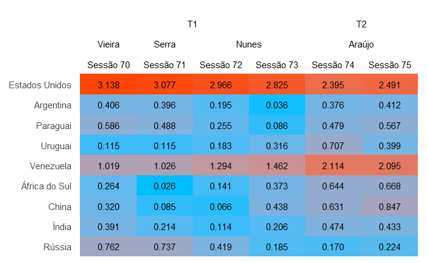

```r
g11 <- ggplot(un_data, aes(x = session.x, y = reorder(
  factor(Countryname.y, levels = rev(levels(factor(Countryname.y)))),-grupo),
  fill=IdealPointDistance))+
  geom_tile()+
  geom_text(aes(label = format(round(IdealPointDistance, 3), size = 3)))+
  scale_fill_gradient(low="deepskyblue", high="orangered") +
  theme_minimal()+
  scale_x_continuous(
    breaks = seq(from = 70, to = 75,by = 1),
    position = "top")+
  labs(y = element_blank(),
       x = element_blank())+
  theme(legend.position = "none",
        axis.ticks = element_blank(),
        axis.text.x = element_blank(),
        axis.ticks.x = element_blank(),
        panel.grid.major = element_blank(),
        panel.grid.minor = element_blank(),
        text = element_text(size = 14))+
  coord_cartesian(xlim = c(69.7,75.3), ylim = c(1, 12))+
  annotate("text", 70, 11, label = "Vieira", size = 4)+
  annotate("text", 71, 11, label = "Serra", size = 4)+
  annotate("text", 72.5, 11, label = "Nunes", size = 4)+
  annotate("text", 74.5, 11, label = "Araújo", size = 4)+
  annotate("text", 70, 10, label = "Sessão 70", size = 4)+
  annotate("text", 71, 10, label = "Sessão 71", size = 4)+
  annotate("text", 72, 10, label = "Sessão 72", size = 4)+
  annotate("text", 73, 10, label = "Sessão 73", size = 4)+
  annotate("text", 74, 10, label = "Sessão 74", size = 4)+
  annotate("text", 75, 10, label = "Sessão 75", size = 4)+
  annotate("text", 71.5, 12, label = "T1", size = 4)+
  annotate("text", 74.5, 12, label = "T2", size = 4)

g11
```

Como a intenção é verificar o impacto da PE bolsonarista, cabe agora criar um segundo banco de dados, que divida o primeiro em dois períodos (T1 e T2), extraindo a média de cada um de modo a permitir o cálculo da diferença entre entre as médias dos dois períodos.

```r
t1 <- un_data %>%
  filter(session.x <= 73)

t1 <- aggregate(t1[,3], list(t1$Countryname.y), mean) %>%
   rename(country = Group.1) %>%
   rename(mean_t1 = IdealPointDistance)

t2 <- un_data %>%
  filter(session.x >= 74)

t2 <- aggregate(t2[,3], list(t2$Countryname.y), mean) %>%
   rename(country = Group.1) %>%
   rename(mean_t2 = IdealPointDistance)

un_change <- merge(t1, t2)
un_change$change <- t2$mean_t2 - t1$mean_t1

un_change$grupo <- recode(un_change$country,
                        "Estados Unidos" = 1,
                        "Argentina" = 2,
                        "Paraguai" = 2,
                        "Uruguai" = 2,
                        "Venezuela" = 2,
                        "China" = 3,
                        "Índia" = 3,
                        "Rússia" = 3,
                        "África do Sul" = 3)

un_change
```

| country | mean_t1 | mean_t2 | change | grupo |
| --- | --- | --- | --- | --- |
| África do Sul | 0.2008646 | 0.6559149 | 0.4550503 | 3 |
| Argentina | 0.2581751 | 0.3939137 | 0.1357386 | 2 |
| China | 0.2270125 | 0.7385956 | 0.5115831 | 3 |
| Estados Unidos | 3.0016497 | 2.4425488 | -0.5591009 | 1 |
| Índia | 0.2311859 | 0.4533719 | 0.2221859 | 3 |
| Paraguai | 0.3536815 | 0.5231686 | 0.1694871 | 2 |
| Rússia | 0.5255857 | 0.1969138 | -0.3286719 | 3 |
| Uruguai | 0.1821571 | 0.5527523 | 0.3705952 | 2 |
| Venezuela | 1.2001543 | 2.1043447 | 0.9041904 | 2 |

Feito isso, os dados estão prontos para se criar a segunda parte do gráfico 1, contendo os valores referentes às variações nas médias entre T1 e T2:

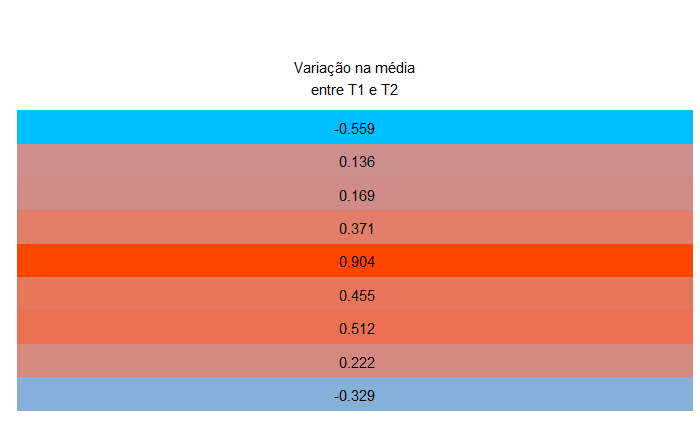

```r
g12 <- ggplot(un_change, aes(x = 1, y = reorder(
  factor(country, levels = rev(levels(factor(country)))), -grupo), fill=change))+
  geom_tile()+
  geom_text(aes(label = format(round(change, 3), size = 3)))+
  scale_fill_gradient(low="deepskyblue", high="orangered")+
  theme_minimal()+
  labs(y = element_blank(),
       x = element_blank())+
  theme(legend.position = "none",
        axis.ticks = element_blank(),
        axis.text.x = element_blank(),
        axis.ticks.x = element_blank(),
        axis.text.y = element_blank(),
        axis.ticks.y = element_blank(),
        panel.grid.major = element_blank(),
        panel.grid.minor = element_blank(),
        text = element_text(size = 12))+
  coord_cartesian(xlim = c(1,1), ylim = c(1, 12))+
  annotate("text", 1, 10.5, label = "Variação na média
entre T1 e T2", size = 4)

g12
```

Para concluir, une-se os dois gráficos:

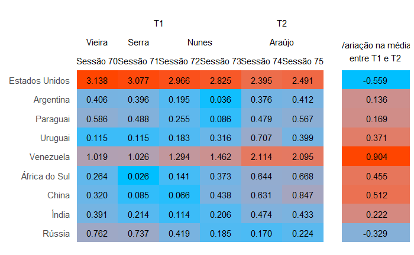

```r
g1 <- plot_grid(g11, g12, align = "h", ncol = 2, rel_widths = c(4/5, 1/5))
g1
```

### Gráfico 2

O gráfico 2 busca identificar se, durante a gestão Araújo, a distância entre os pontos ideiais do Brasil com os os demais países analisados se caracterizou como pontos *outliers* dentro do período democrático brasileiro. Assim, recorre a um período maior que o anterior, demandando um novo recorte do banco de dados original.

```r
un_data2 <- dfAgree %>%
  filter(session.x >= 40) %>%
  filter(iso3c.x == "BRA") %>%
  filter(iso3c.y == "USA"
         |iso3c.y == "ARG"
         |iso3c.y == "PRY"
         |iso3c.y == "URY"
         |iso3c.y == "VEN"
         |iso3c.y == "CHN"
         |iso3c.y == "RUS"
         |iso3c.y == "IND"
         |iso3c.y == "ZAF") %>%
  ungroup(ccode1) %>%
  select(session.x, iso3c.y, IdealPointDistance)

un_data2
```

| session.x | iso3c.y | IdealPointDistance |
| --- | --- | --- |
| 40 | USA | 2.82555186 |
| 40 | VEN | 0.18257684 |
| 40 | PRY | 0.60439166 |
| 40 | ARG | 0.09565026 |
| 40 | URY | 0.05578753 |
| 40 | RUS | 1.51238814 |
| 40 | CHN | 0.13392906 |
| 40 | IND | 0.55985884 |
| 41 | USA | 2.95570021 |
| 41 | VEN | 0.05437426 |

[output cut: 305 more lines]

Similarmente, como a intenção é comparar a gestão Araújo com demais anos da amostra, é necessário gerar um novo banco de dados, que separe os anos nos quais o ex-ministro esteve à frente do MRE.

```r
araujo <- un_data2 %>%
  filter(session.x >= 74)

araujo
```

| session.x | iso3c.y | IdealPointDistance |
| --- | --- | --- |
| 74 | USA | 2.3945400 |
| 74 | VEN | 2.1135160 |
| 74 | PRY | 0.4792812 |
| 74 | ARG | 0.3759127 |
| 74 | URY | 0.7066213 |
| 74 | RUS | 0.1696597 |
| 74 | ZAF | 0.6436731 |
| 74 | CHN | 0.6306261 |
| 74 | IND | 0.4739612 |
| 75 | USA | 2.4905576 |

[output cut: 8 more lines]

Com os dados tratados, avança-se para o gráfico, destacando em vermelho os anos da gestão Araújo.

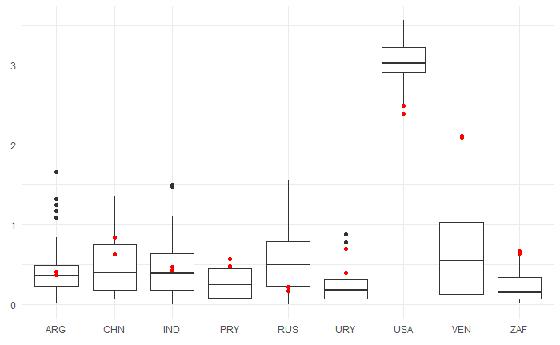

```r
g2 <- ggplot(un_data2, aes(x = iso3c.y, y = IdealPointDistance))+
  geom_boxplot()+
  geom_point(data = araujo, color = "red")+
  theme_minimal()+
  labs(x = element_blank(),
       y = element_blank())

g2
```

Por último, para garantir a preservação dos dados, exporta-se as bases de dados e os plots gerados para os formatos csv e png:

```r
#bases de dados
write.csv(un_data, file = "filtered_data/un_data.csv")
write.csv(un_change, file = "filtered_data/un_change.csv")
write.csv(un_data2, file = "filtered_data/un_data2.csv")
write.csv(araujo, file = "filtered_data/araujo.csv")


#plots
png(filename = "plots/g11.png")
plot(g11)
dev.off()

png(filename = "plots/g12.png")
plot(g12)
dev.off()

png(filename = "plots/g1.png", width = 600)
plot(g1)
dev.off()

png(filename = "plots/g2.png")
plot(g2)
dev.off()
```

### Conclusão:

Embora a gestão Bolsonaro/Araújo do MRE tenha de fato se aproximado dos EUA, essa aproximação provavelmente só se deu em pautas na quais os EUA fizeram forte lobby sobre a delegação brasileira, fugindo muito pouco da normalidade dos padrões históricos construídos entre os dois Estados e mantendo suas votações consideravelmente afastadas. A maior mudança foi com relação a vizinha Venezuela, onde foi acentuada a tendencia de afastamento que se iniciou ainda durante a gestão de Aloysio Nunes no comando do ministério. Apesar da retórica anti-China propagada pela presidência, os votos de Brasil e China se mantiveram próximos, ficando dentro da normalidade do padrão construído desde a redemocratização brasileira.